# Supervised Bayesian Matrix Factorization Identifies Prognostic Gene Expression Programs

Project Update

Andrew Walther

Department of Biostatistics, UNC Gillings School of Global Public Health

August 27, 2026

## Agenda

**Background.** The PDAC prognostic problem, and why to supervise the factorization

**Method.** The joint model, explicit priors, the ELBO, CAVI inference, preprocessing, and a new two-stage approach to selecting $K$

**Results.** A synthetic validation of the $K$-selection approach, then real PDAC data: gene programs, survival, and the joint model vs. the unsupervised two-step

**Impact & Future Directions**

# Background

## Background: PDAC needs molecular prognosis

- **Five-year survival under 12%**, among the most lethal solid tumors
- Most patients diagnosed late; **no widely adopted molecular stratification** at diagnosis
- Bulk expression mixes malignant, stromal, and immune signals, so prognostic structure is interwoven and often **low-variance**
- **Goal:** recover *gene expression programs (GEPs)* whose activation predicts survival, and validate them on **independent** cohorts
- A GEP is a coordinated set of genes (a column of $F$) whose patient-level activation (a column of $L$) we test for survival association

**Why model expression and survival *jointly*?**

The common pipeline is **two-step**: run unsupervised factor analysis (PCA / EBMF), then test factors for survival *post hoc*.

- Unsupervised axes track the **largest expression variance**, often batch or housekeeping signal
- A program explaining little variance but strongly prognostic gets **missed**
- **Supervision** steers factors toward survival-relevant structure *during* estimation

A program explaining 15% of variance may be pure batch effect; one explaining 3% may cleanly separate survivors. Supervision prioritizes the second.

# Methods

## The model: two coupled components

$$\underbrace{Y = LF^\top + E,\quad E_{ij}\sim N(0,\tau_j^{-1})}_{\text{genomics: low-rank} + \text{gene-specific noise}}
\qquad
\underbrace{h_i(t)=h_0(t)\exp(\eta_i)}_{\text{Cox proportional hazards}}$$

| Quantity | Dim | Meaning |
| --- | --- | --- |
| $Y$ | $n\times p$ | expression matrix |
| $L$ | $n\times K$ | patient program-activation scores |
| $F$ | $p\times K$ | gene weights per program |
| $\beta$ | $K\times 1$ | survival (log-HR) coefficients |
| $\tau_j$ | scalar | gene-specific noise precision |
| $\eta_i$ | scalar | patient log-risk score, $(Y_iF)\beta$ |

**Shared $F$ couples the two**

The **same** gene-program weights $F$ drive both the low-rank reconstruction of $Y$ **and** the survival risk score $\eta = (YF)\beta$. A program is **prognostic only if its $\beta_k \neq 0$**; otherwise it explains expression alone.

**Non-parametric baseline hazard**

$h_0(t)$ is left **unspecified**; it cancels in the Cox partial likelihood. No Weibull / exponential shape assumption, only proportional hazards.

## The model: projection predictor and explicit priors

### Projection predictor: $\eta = (YF)\beta$

- Risk uses the **direct genomic projection** $YF$, not a re-derived patient score
- **Exact** out-of-sample scoring: $\eta_\text{new} = (Y_\text{new}F)\beta$ is the *identical* formula at train and test, so there is no train/test score mismatch
- $L$ is fit for the genomics reconstruction only; it does not enter the survival likelihood

**Why the projection form**

Leakage-free **exact** external scoring, with no OLS re-projection step for new patients. This is what makes external validation on held-out cohorts a clean apples-to-apples comparison.

**Priors: every block is explicit.** $q(\cdot)$ denotes the **variational (approximate posterior)** for each block, fit by empirical Bayes at every update:

- $q(L_{\cdot k}),\, q(F_{\cdot k})$: **point-exponential** (non-negative spike-and-slab), $\;g(\theta)=\pi_0\delta_0+(1-\pi_0)\,\text{Exp}(\lambda),\ \theta\ge 0$
- $q(\beta_k)$: **normal** (Gaussian slab, no spike at zero), $\;g(\beta)=N(0,\sigma^2)$
- $q(\tau_j)$: **closed-form MLE**, no EBNM, no prior tuning

Sparsity $\pi_0$, scale $\lambda$, and slab variance $\sigma^2$ are all estimated from the data (`ebnm`) at each step.

**Why a normal prior on $\beta$, not a spike-and-slab**

A spike-and-slab prior forces a hard in/out decision on each factor as part of fitting. A normal prior instead lets $\hat\beta_k$ shrink **continuously** toward zero for a factor with no survival signal, without ever forcing it to exactly zero. That continuous shrinkage is what Automatic Relevance Determination (ARD) means here, and it is the raw material Stage 2 of $K$ selection (two slides ahead) turns into a discrete active/inactive call, by thresholding $|\hat\beta_k|$ after fitting rather than building the threshold into the prior itself.

## The objective: ELBO & variational family

**Mean-field variational family:** each block factorizes independently:

$$q(L,F,\beta,\tau)=\prod_{k=1}^{K}q(L_{\cdot k})\;\prod_{k=1}^{K}q(F_{\cdot k})\;\prod_{k=1}^{K}q(\beta_k)\;\prod_{j=1}^{p}q(\tau_j)$$

The **ELBO** (evidence lower bound) is the objective CAVI maximizes, a lower bound on the log marginal likelihood. For the projection model:

$$\text{ELBO}=\underbrace{E_q[\mathcal{L}_\text{gen}]}_{\text{expression fit}}\;+\;\underbrace{\lambda\,E_q[\mathcal{L}_\text{Cox}]}_{\text{survival fit}}\;-\;\underbrace{\textstyle\sum_\text{blocks}D_\text{KL}\!\left(q\,\|\,\text{prior}\right)}_{\text{prior regularization}}$$

- **Genomics fit** $E_q[\mathcal{L}_\text{gen}]=\sum_j E_q\log p(Y_{\cdot j}\mid L,F_j,\tau_j)$: Gaussian reconstruction of $Y$ by $LF^\top$
- **Survival fit**, the projection predictor written out explicitly:
  $$E_q[\mathcal{L}_\text{Cox}] \approx \log PL(\eta_0) - \tfrac12\textstyle\sum_i w_i\sum_k (YF)_{ik}^2\,\text{Var}_q(\beta_k),\quad \eta_0=(YF)\,E_q[\beta]$$
  a **2nd-order Taylor** expansion of the Cox partial log-likelihood around $\eta_0$, the point estimate of $(YF)\beta$. Because $YF$ is treated as data (not a random quantity with its own posterior variance) once $F$ is fixed, only $\beta$’s posterior uncertainty survives in the variance term. This is what keeps the survival term conjugate to the EBNM updates.
- **KL term** penalizes each posterior $q$ away from its prior: the adaptive shrinkage
- The **shared $F$** enters both likelihood terms, genomics reconstruction ($Y \approx LF^\top$) and survival risk ($\eta = (YF)\beta$); that coupling *is* the supervision
- The ELBO **balances** expression and survival automatically, with **no tuning parameter $\alpha$** ($\lambda=1$ in the recommended fits)

> **What the ELBO is *for*:** it is the **fitting objective**. CAVI maximizes it, and a fit is declared converged when it stops improving. It is also **one of four criteria**, alongside BIC, log-likelihood, and cross-validated external C-index, used to choose $K_\text{init}$ (next: *Selecting $K$*).

## Inference: factor-wise CAVI

**Coordinate ascent (Gauss–Seidel):** per outer iteration, for each factor $k$:

$$\beta_k \;\to\; L_{\cdot k} \;\to\; F_{\cdot k}, \qquad \text{then } \tau \text{ once per sweep}$$

- Each update is an **EBNM** sub-problem: pseudo-data $x=B/A$, scale $s=1/\sqrt{A}$, then `ebnm` returns the posterior mean **and** variance
- $\beta_k$ has precision governed by the projection score’s own variance across patients, so a factor with **no survival signal** shrinks $\beta_k \to 0$ on its own: the mechanism ARD relies on
- The empirical-Bayes prior $\hat g$ is **re-estimated every update**, giving adaptive shrinkage per factor and per gene; the residual is deflated after each factor

**Convergence.** After a 5-iteration burn-in, stop when the **ELBO stops improving**: its relative change between iterations falls below $10^{-5}$:
$$\frac{\big|\text{ELBO}^{(t)}-\text{ELBO}^{(t-1)}\big|}{\big|\text{ELBO}^{(t-1)}\big|} < 10^{-5}$$

- The ELBO is the **single objective** being maximized, so this directly detects a stationary point of the variational optimization
- Mean absolute changes in $L$ and $\beta$ are tracked alongside as **diagnostics** (both settle below $10^{-3}$ at convergence)

**Risk-direction sign correction**

Cox concordance is invariant to a global sign flip, so an unconstrained fit can land at $C<0.5$. **Fix:** after convergence, orient $\beta$ against the **training** concordance (flip its sign if $C_\text{train}<0.5$), and carry that same orientation into every downstream use of $\beta$, including test scoring.

## Preprocessing is crucial: per-platform normalization

**The $p\gg n$ scaling problem.** Merging platforms (RNA-seq, microarray, proteomics) leaves each gene on a different scale. The survival precision for program $k$ is
$$A_k=\sum_i w_i\,(YF)_{ik}^2,$$
where $w_i$ = the patient’s **Cox working weight** (curvature from the survival Taylor step) and $(YF)_{ik}$ = patient $i$’s **projection score** on program $k$. Without correction, between-platform variance inflates $(YF)$ unevenly, **swamps $A_k$**, and the survival coefficients **collapse to $\beta\to 0$**.

**The fix: normalize *per platform, before merging*:**

1. Log2 transform (RNA-seq only)
2. **Per-cohort gene selection** (combined rank of mean × variance), top-3000 per cohort, then **intersect** → **2064 genes** in the merged training matrix
3. **Per-platform z-standardization** (each cohort centered/scaled on its own)
4. Row-bind into the merged training matrix

**Skip per-platform normalization → β collapses**

In an 18-configuration benchmark, **10 of 12** pipelines that do **not** z-standardize per platform before merging drive $\beta\to0$.

**No leakage**

Normalization is fit **within each training cohort, before** any split; held-out cohorts get the *same* per-cohort recipe at scoring time.

## Selecting the number of programs: a two-stage framework

**Stage 1: $K_\text{init}$, by a consensus of four fit/prediction criteria.** Fit at several $K_\text{init}$; compare ELBO, BIC, an ELBO-style joint log-likelihood, and cross-validated external C-index across the grid.

**Stage 2: the active-factor subset, by ARD.** Fit once at the chosen $K_\text{init}$; the normal prior on $\beta$ (previous slide) lets Automatic Relevance Determination shrink unneeded factors’ $\beta_k \to 0$ **on its own**, without a second per-K validation loop.

### Stage 1: choosing $K_\text{init}$

- **ELBO**: the fitting objective itself, compared *across* $K_\text{init}$
- **BIC** $= -2\,\text{LL} + \log(n)\cdot\text{df}$, $\text{df}=K_\text{init}\cdot(n+p+1)$, a complexity penalty that is **not** guaranteed to agree with ELBO or external C
- **Log-likelihood**: genomics + survival, an ELBO-style bound (not an exact marginal likelihood)
- **Cross-validated external C-index**: the only *generalization* signal among the four, evaluated on the five held-out cohorts
- These need **not** agree; see *Results* for the full $K_\text{init}=2\text{-}20$ sweep, with each metric’s own direction of improvement made explicit

### Stage 2: ARD classification at fixed $K_\text{init}$

Each factor $k$ is classified by `classify_factors()`:

- **survival-active**: $|\hat\beta_k| > 0.001$
- **genomics-only**: not survival-active, but $\text{PVE}_k > 1\%$
- **dead**: neither, fully pruned

**Running example: $K_\text{init}=7$**

7 starting factors $\to$ **2 survival-active** + **2 genomics-only** (4 kept, 3 pruned). Stable across a wide range of $K_\text{init}$; see *Results*.

# Results

## Data: Synthetic Validation & PDAC Cohorts

### Multi-cohort simulation

**EBMF-grounded ground truth**: shared factors (present in all studies) plus study-specific factors. **Shared factors carry the survival signal**; study-specific factors do not.

**Scenarios**

- *All Shared Factors*: every program is shared and prognostic
- *All Cohort-Specific Factors*: negative control, no shared signal ($\eta\equiv 0$)
- *Shared & Cohort-Specific Factors*: the realistic mix

**Model Arms**

- Unsupervised two-step (EBMF → Cox)
- The projection-predictor joint model, $K$ selected by over-specified $K_\text{init}$ plus ARD pruning, mirroring the real-data procedure

### PDAC cohorts: External Validation

- **Train:** TCGA-PAAD + CPTAC ($n\approx 273$, RNA-seq + proteomics)
- **Validate:** 5 fully held-out cohorts, scored by the **exact** projection formula $\eta=(Y_\text{new}F)\beta$

| Held-out cohort | Platform |
| --- | --- |
| Dijk | RNA-seq |
| Moffitt | Microarray |
| PACA-AU (array) | Microarray |
| PACA-AU (seq) | RNA-seq |
| Puleo | Microarray |

## Synthetic Results: over-specifying $K_\text{init}$ doesn’t hurt performance

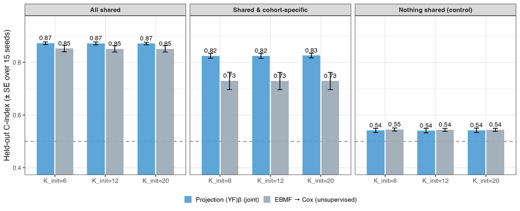

**Figure.** Held-out C-index by $K_\text{init}$, arm, and scenario (mean ± SE over 15 seeds; dashed line = chance).

- **$K_\text{init}=6$** means the model was told the true number of factors directly (an idealized case used only as a reference point, never available on real data); **$K_\text{init}=12/20$** is the over-specified-plus-ARD-pruning procedure actually used
- **C-index (and, in the appendix-detail figure, factor recovery and specificity) are flat across $K_\text{init}=6\to12\to20$** in every scenario: giving the model more starting factors than it needs and trusting ARD to prune costs nothing relative to knowing the true count in advance
- Bars are the mean over 15 seeds (up from 5, for a properly powered comparison); error bars are $\pm$ 1 standard error across those 15 seeds

## Synthetic Results: does a larger $K_\text{init}$ create more false alarms?

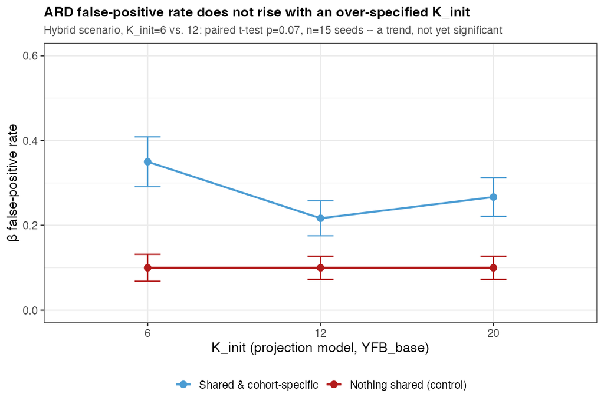

**Figure.** $\beta$ false-positive rate: how often a factor with *no* true survival effect is nonetheless called survival-active, vs. $K_\text{init}$ (projection model only; EBMF has no survival coefficient to test this on). Mean ± SE over 15 seeds.

- **The question:** giving the model more factors than it needs gives ARD more non-signal factors it *could* mistakenly call survival-active. Does the false-positive rate actually rise as $K_\text{init}$ grows?
- **The answer, so far: no.** In the realistic scenario the false-positive rate is numerically *lower* at $K_\text{init}=12/20$ than at $K_\text{init}=6$ (0.35 → 0.22 → 0.27), though a paired test between $K_\text{init}=6$ and 12 gives $p=0.07$, so call this a consistent trend, not yet a statistically confirmed one. In the negative-control scenario the rate is flat at 0.10 regardless of $K_\text{init}$.
- Consistent with a separate point raised in discussion: even when a non-signal factor does pick up a small, nonzero coefficient, that coefficient is too small to meaningfully move the risk score

## Joint model vs. two-step as survival signal strength varies

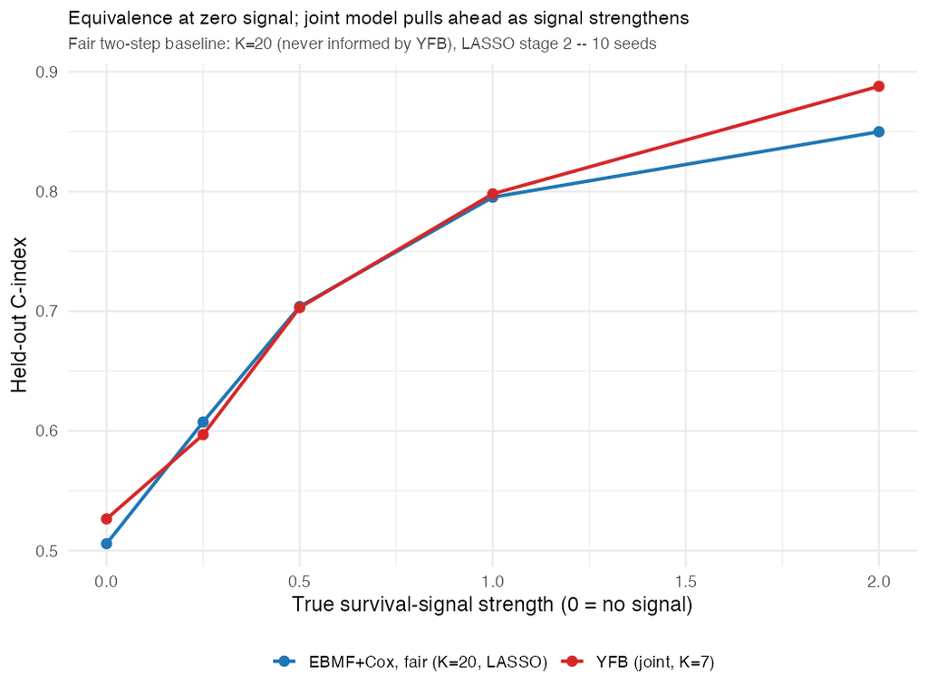

**Figure.** External performance of the joint model vs. the unsupervised two-step (EBMF → Cox) as the simulated survival-signal strength increases. “Strength” is a multiplier on the true survival coefficients used to generate each simulated patient’s survival time (values swept: 0, 0.25, 0.5, 1, 2; strength = 1 is this project’s standard “realistic-magnitude” setting). At strength = 0 (no true survival signal at all), the joint model matches EBMF: supervision costs nothing when there is nothing to exploit. At strength = 2 (twice the realistic magnitude), the joint model pulls ahead.

- **Strength = 0:** joint $\approx$ EBMF-only. The joint model does not fabricate prognostic signal when none exists.
- **Strength = 2:** joint model outperforms the two-step. Supervision helps *only when there is signal to find*, and does not hurt when there isn’t.
- With only 10 replicate seeds, no single strength level individually reaches statistical significance; the pattern across the sweep is the evidence, not any one point

## PDAC Cohorts: Prognostic Gene Programs

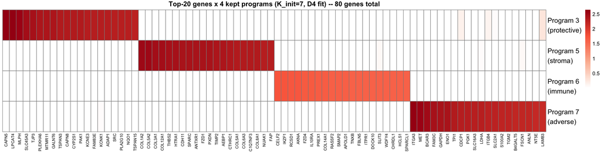

**Figure.** Top-20 genes by loading weight for each of $K_\text{init}=7$’s 4 kept factors (the other 3, fully pruned, are omitted), rows = programs, columns = genes. Weights are **non-negative** (point-exponential prior); the block-diagonal structure means each program’s top genes carry near-zero weight in the other 3.

- $K_\text{init}=7$ (ELBO / BIC / log-likelihood / external-C consensus; see the sweep later) $\to$ **2 survival-active** + 2 genomics-only kept: Program 3 (**protective**) and Program 7 (**adverse**), classified by the sign of each program’s fitted Cox coefficient $\hat\beta_k$ (positive $\to$ higher activation, shorter survival, adverse; negative $\to$ longer survival, protective)
- The 2 survival-active programs are characterized by **5 methods**: gene-set enrichment (fgsea, Fast Gene Set Enrichment Analysis, and ORA, Over-Representation Analysis), correlation with the PurIST classical/basal subtype score, hazard-ratio consistency across all 5 external cohorts, and gene-list overlap with the lab’s published DeSurv factors
- The 2 genomics-only programs carry **weaker evidence**: their top-weighted genes were characterized by gene-set enrichment (fgsea) and overlap with the lab’s published DeSurv factors, the only 2 of the 5 methods that apply without a survival signal — **Program 5** reads as **desmoplastic stroma** (7 collagen genes, SPARC, THBS2, FAP) and **Program 6** as **immune infiltrate** (IKZF1, AKNA, IL10RA, HCLS1); unlike Programs 3/7, their labels have not been tested for reproducibility across cohorts

## PDAC Cohorts: Prognostic Association

The two survival-active programs stratify patients (split at median **projection score $(YF)_k$**, the quantity the model scores on):

- **Adverse, Program 7** (higher activation → shorter survival), log-rank $p=0.00047$
  - top genes: *ITGA3, MET, BCAR3, FAM3C, GAPDH, ENO1, TPI1, PGK1*
- **Protective, Program 3** (higher activation → longer survival), log-rank $p=0.0077$
  - top genes: *CAPN5, LPCAT4, MLPH, SLC45A3, TJP3, PLEKHA6, MTMR11, GALNT6*

Proportional-hazards assumption not violated (Schoenfeld test).

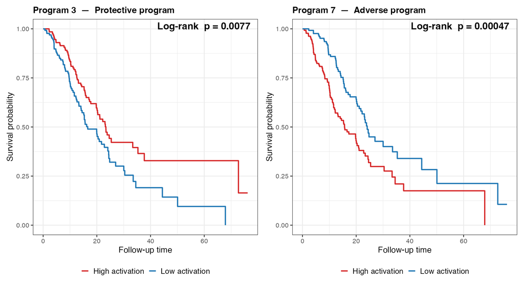

**Figure.** Kaplan–Meier curves for the two survival-active programs, patients split at the median projection score $(YF)_k$ in the training cohorts. The adverse program’s high-activation group has worse survival; the protective program’s, better. Direction read empirically from the curves.

## Choosing $K_\text{init}$: the consensus sweep

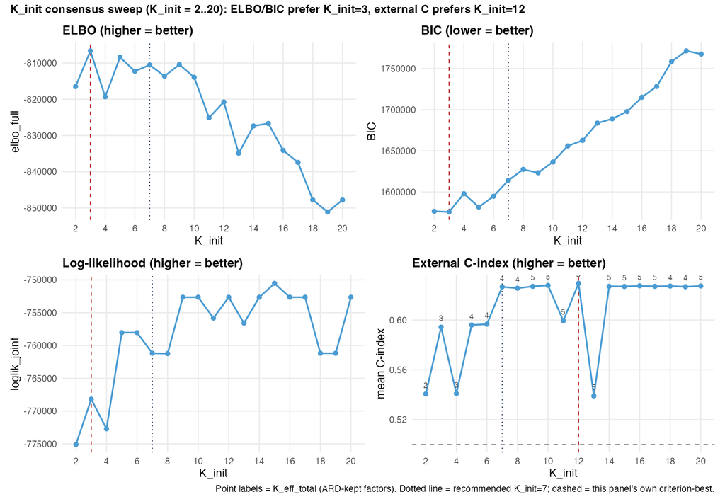

## Joint model vs. the unsupervised two-step

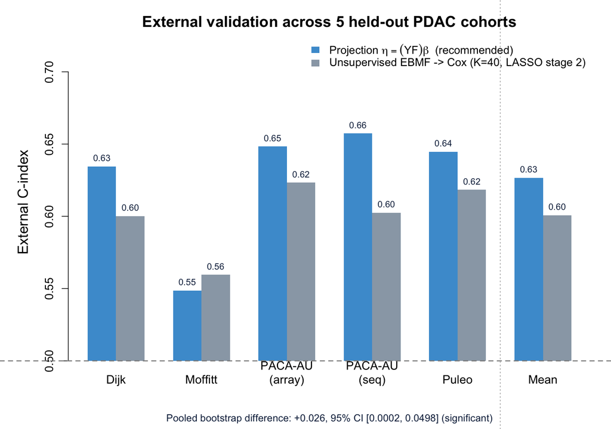

**Figure.** External C-index across the five held-out PDAC cohorts (+ mean): the recommended projection model vs. the fairest independent two-step baseline (EBMF → Cox, $K=40$, LASSO stage 2). $K=40$ is a large factor count the two-step method was never told YFB’s answer to, with a regularized second stage rather than a small $K$ or an unregularized `coxph()` that overfits at $K=40$. Dashed line = chance.

- **Projection model mean C = 0.627** · unsupervised EBMF → Cox (K=40, LASSO) 0.601, across the five held-out cohorts
- Pooled bootstrap difference: **+0.026, 95% CI [0.0002, 0.0498]**, n=616 pooled across cohorts, **significant**
- $K_\text{init}=7$ (ELBO / BIC / log-likelihood / external-C consensus) $\to K_\text{eff}=2$ survival-active of 4 kept

## Model Comparison Summary

[output not shown]

Real ext. C = mean across 5 held-out PDAC cohorts. **K_init** = starting factor count, selected by an ELBO / BIC / log-likelihood / external-C consensus (Stage 1); **K_eff** = survival-active programs by ARD, $|\hat\beta| > 10^{-3}$ (Stage 2), for the projection model. For the two-step baseline, **K_eff** is the number of the 40 EBMF factors that keep a nonzero coefficient after LASSO-regularized, cross-validated stage-2 Cox fitting: a different mechanism from ARD (L1 shrinkage vs. an ARD prior on $\beta$), but it answers the same question of how many factors the model actually uses. Gene selection ranks genes by combined mean × variance per cohort.

**On gene selection**

The combined-rank selection recipe was **motivated by** the lab’s penalized survival-MF (DeSurv) preprocessing; here it is applied within the fully Bayesian model.

## Impact / key findings

1. **Joint supervision beats the unsupervised two-step**, and costs nothing when there is no survival signal to exploit (signal-strength sweep).
2. **Preprocessing is decisive.** Per-platform z-standardization before merging is the difference between a working model and $\beta\to 0$; **10 of 12** alternatives collapse.
3. **$K$ selection is a two-stage split.** Cross-validated external C-index, with ELBO, BIC, and log-likelihood, helps pick $K_\text{init}$; ARD shrinkage then determines the survival-active subset ($K_\text{eff}=2$) directly from that single over-specified fit, with no separate per-K validation loop needed for $K_\text{eff}$ itself.
4. **Over-specifying $K_\text{init}$ and trusting ARD costs nothing.** Confirmed in simulation (15 seeds): recovery, specificity, and C-index are flat whether the model starts at the true $K$ or 3x over-specified.
5. **Mean external C-index = 0.627** across five independent PDAC cohorts, fully Bayesian throughout (adaptive priors, no $\alpha$ tuning, uncertainty-aware).

### Limitations

- **It is not obvious which $K_\text{init}$ is best.** BIC and ELBO favor a much smaller $K_\text{init}$ than external C-index does; that disagreement is shown on the sweep slide rather than resolved by picking whichever criterion agrees with us
- **The ARD retention thresholds ($\text{PVE}>1\%$, $|\hat\beta|>0.001$) are not literature-derived.** The $\hat\beta$ cutoff was reverse-engineered from this model’s own coefficient scale, not taken from a principled sparse-factor-model source; a literature check and a sensitivity sweep are still open. A fixed threshold on $\hat\beta_k$ also assumes every factor’s projection score is on a comparable scale: each factor’s loading vector is unit-normalized (removing the dominant scale gap), but that does not guarantee equal projection-score *variance* across factors, which is a further open question
- **Small external cohorts give noisy estimates.** Per-cohort C ranges down to 0.55 (Moffitt), near chance
- The 2 survival-active programs are **statistically prognostic and biologically annotated by 5 independent methods** (Program 7 basal-like/adverse, Program 3 classical/protective); the 2 genomics-only programs’ labels rest on weaker evidence (2 of those methods, not externally validated) and a matched head-to-head against DeSurv on one protocol both remain open

## Future directions & summary

### Current status

- **$K$ selection**: cross-validated external C-index, ELBO, BIC, and log-likelihood inform $K_\text{init}$; ARD shrinkage determines $K_\text{eff}$
- **Gene programs biologically annotated**: the 2 survival-active programs by the 5 methods on the gene-programs slide; the 2 genomics-only programs more tentatively, by 2 of those methods

### Next steps

1. **Multiple cohorts / multiple modalities via indicator columns in $L$**: stack methylation and expression, possibly with modality-specific priors; leave-one-study-out validation; train on A vs. B vs. A+B
2. **Manuscript preparation**: methods-primary framing, PDAC as the application

### Summary

1. Joint supervised factorization via the projection predictor $(YF)\beta$; **point-exponential priors on $L,F$, a normal prior on $\beta$**, non-parametric baseline hazard
2. **Preprocessing is crucial**: per-platform normalization prevents the survival precision from being dominated and $\beta$ from collapsing
3. **$K$ selection: cross-validated external C-index, ELBO, BIC, and log-likelihood inform $K_\text{init}$; ARD shrinkage determines $K_\text{eff}$**, validated on real data (five external PDAC cohorts, mean C = 0.627) and synthetic data with known ground truth
4. **Recommended model**
   - Linear predictor: projection $(YF)\beta$
   - $L$ cohort indicator: No (candidate direction for multi-cohort/multi-modality extension, above)
   - Pre-processing: per-platform z-std
   - $K_\text{init} = 7$ $\to K_\text{eff} = 2$, mean external C = **0.627**

## Discussion

### Thank You

**Questions, suggestions, and feedback welcome!**

Andrew Walther · awalther@unc.edu

Department of Biostatistics, UNC Gillings School of Global Public Health

# Appendix

## Appendix: $K_\text{init}$ sweep, full table

| K_init | Surv-active | Genomics-only | Dead | K_eff (kept) | ELBO | BIC | Log-lik | External C |
| --- | --- | --- | --- | --- | --- | --- | --- | --- |
| 2 | 1 | 1 | 0 | 2 | -816,495 | 1,576,416 | -775,093 | 0.5406 |
| 3 | 1 | 2 | 0 | 3 | -806,636 | 1,575,712 | -768,183 | 0.5943 |
| 4 | 1 | 2 | 1 | 3 | -819,328 | 1,597,855 | -772,698 | 0.5409 |
| 5 | 3 | 1 | 1 | 4 | -808,404 | 1,581,651 | -758,038 | 0.5960 |
| 6 | 3 | 1 | 2 | 4 | -812,248 | 1,594,760 | -758,035 | 0.5967 |
| 7 | 2 | 2 | 3 | 4 | -810,540 | 1,614,174 | -761,185 | 0.6267 |
| 8 | 2 | 2 | 4 | 4 | -813,629 | 1,627,379 | -761,230 | 0.6256 |
| 9 | 2 | 3 | 4 | 5 | -810,421 | 1,623,321 | -752,643 | 0.6271 |
| 10 | 2 | 3 | 5 | 5 | -813,944 | 1,636,429 | -752,640 | 0.6279 |
| 11 | 3 | 2 | 6 | 5 | -825,096 | 1,655,903 | -755,819 | 0.5994 |
| 12 | 2 | 3 | 7 | 5 | -820,752 | 1,662,678 | -752,649 | 0.6295 |
| 13 | 3 | 2 | 8 | 5 | -834,897 | 1,683,664 | -756,585 | 0.5390 |
| 14 | 2 | 3 | 9 | 5 | -827,366 | 1,688,890 | -752,641 | 0.6271 |
| 15 | 2 | 3 | 10 | 5 | -826,682 | 1,697,778 | -750,527 | 0.6270 |
| 16 | 2 | 3 | 11 | 5 | -834,100 | 1,715,115 | -752,638 | 0.6275 |
| 17 | 2 | 3 | 12 | 5 | -837,425 | 1,728,238 | -752,642 | 0.6271 |
| 18 | 2 | 2 | 14 | 4 | -847,771 | 1,758,428 | -761,180 | 0.6273 |
| 19 | 2 | 2 | 15 | 4 | -851,099 | 1,771,549 | -761,183 | 0.6268 |
| 20 | 2 | 3 | 15 | 5 | -847,800 | 1,767,584 | -752,643 | 0.6274 |

Highlighted row = the recommended $K_\text{init}=7$. External C = mean C-index across the 5 held-out PDAC cohorts. BIC and Log-lik are ELBO-style bounds, not exact marginal-likelihood quantities.

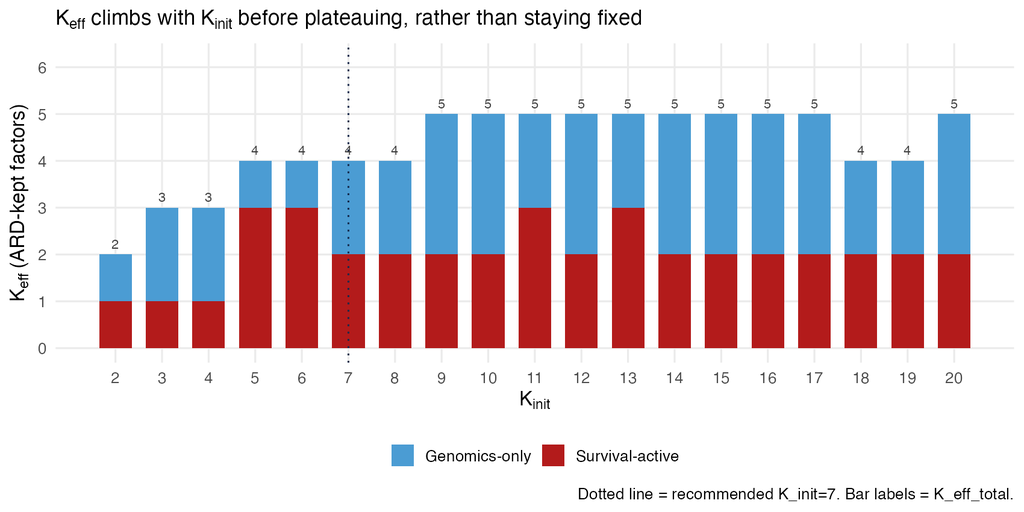

**Figure.** $K_\text{eff}$ (ARD-kept factor count) by $K_\text{init}$, split survival-active vs. genomics-only. $K_\text{eff}$ steps up from 2 at $K_\text{init}=2$ to a plateau of 5 by $K_\text{init}\approx9$, rather than staying fixed as $K_\text{init}$ grows.

## Appendix: simulation detail, factor recovery & specificity

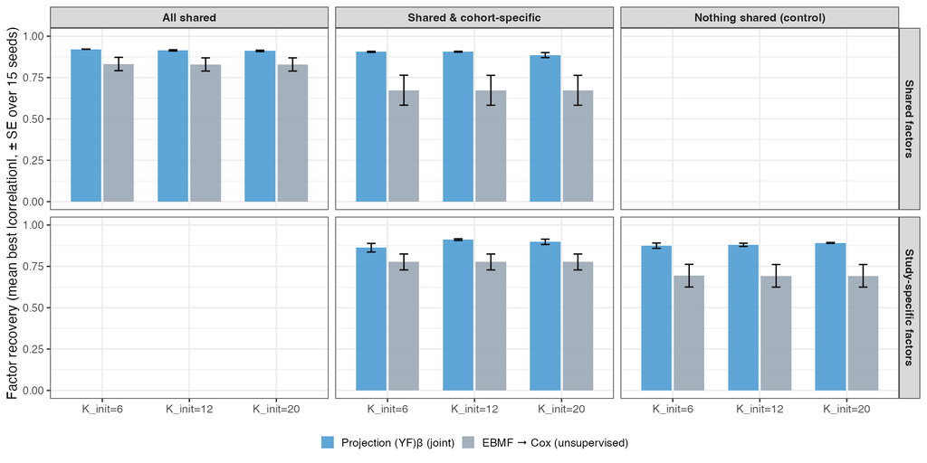

**Figure A.** Factor recovery (mean best $|$correlation$|$ vs. the true gene programs) by $K_\text{init}$, arm, and scenario (mean ± SE, 15 seeds).

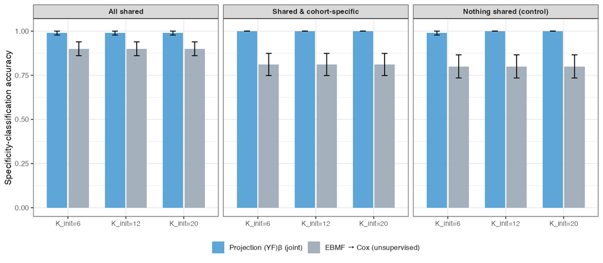

**Figure B.** Specificity-classification accuracy (fraction of factors correctly typed shared vs. study-specific) by $K_\text{init}$ and scenario (mean ± SE, 15 seeds).

- The same flat-across-$K_\text{init}$ pattern shown by C-index in the main results holds for recovery and specificity too, in every scenario

## Appendix: convergence & survival-activity magnitudes

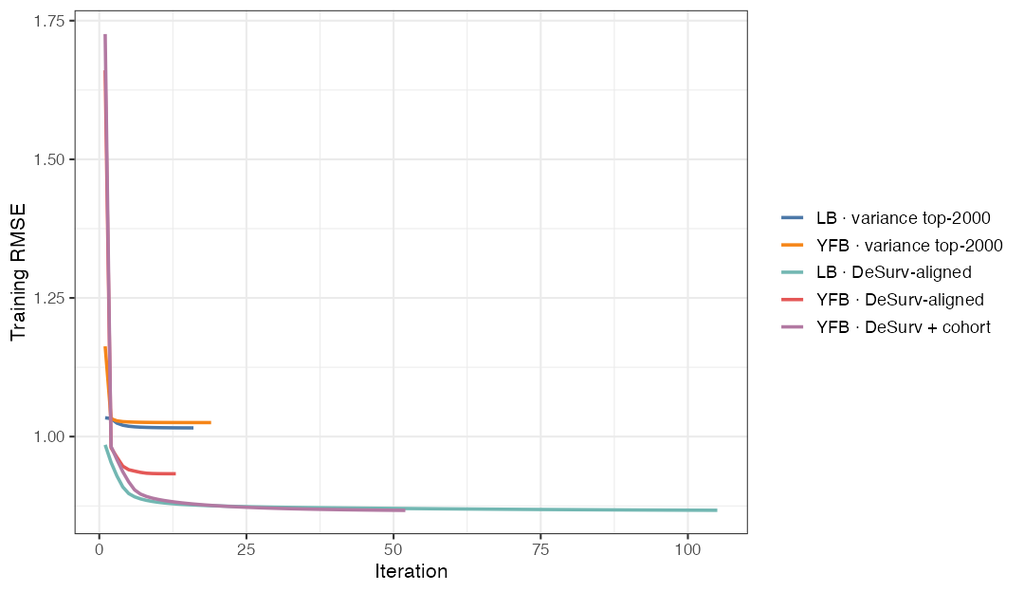

**Figure A1.** Training RMSE convergence traces across model configurations. RMSE stabilizes to a plateau; stopping is governed by the relative ELBO change falling below $10^{-5}$ ($\Delta L,\Delta\beta$ tracked as diagnostics).

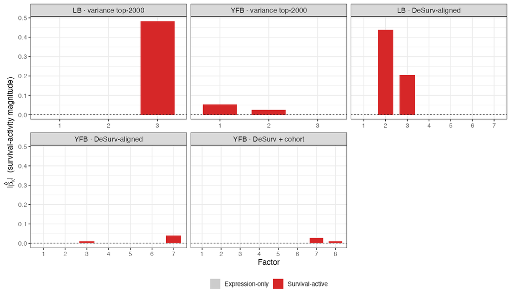

**Figure A2.** Survival-activity magnitude $|\hat\beta_k|$ per program. Most programs fall below the activity threshold (expression-only); a small number clear it (survival-active).

- The spike-and-slab / shrinkage behavior is visible: most programs are shrunk below the survival-activity threshold, with only the survival-active ones retained

## Appendix: relation to DeSurv (Young et al., PNAS 2026)

**Same design and same data: SBMF is the Bayesian counterpart.** Both jointly fit supervised NMF + Cox with **non-negative gene programs**, share the same training set (**TCGA + CPTAC, $n=273$**) and the **same five external PDAC cohorts** (Dijk, Moffitt, PACA-AU array/seq, Puleo; $n=616$), score new patients by **projection** (no retraining), and use the **combined-rank top-3000-per-cohort** gene selection. Both also find that the **highest-variance program is *not* the most prognostic**.

DeSurv objective: $(1-\alpha)\,\mathcal{L}_\text{NMF} - \alpha\,\mathcal{L}_\text{Cox}$, with the survival gradient on the gene programs $W$.

**What SBMF changes**

|  | DeSurv | SBMF |
| --- | --- | --- |
| Estimation | penalized optimization | Bayesian variational (CAVI) |
| $K$ selection | Bayesian-optimization over $k,\alpha,\lambda$ jointly | ARD shrinkage + ELBO/BIC/log-likelihood/external-C consensus on $K_\text{init}$ only |
| Shrinkage | fixed elastic-net | empirical-Bayes priors (learned) |
| Uncertainty | point estimates | posterior mean **+** variance |
| Noise | least-squares | per-gene precision $\tau$; $E[L^2]$ correction |

- **DeSurv:** $k=3,\ \alpha=0.334$; pooled external **HR/SD $=1.50$** (95% CI 1.31–1.72)
- **SBMF (YF)β:** $K_\text{init}=7\to K_\text{eff}=2$; mean external **C $=0.627**

**Caveat:** the two report different primary metrics (DeSurv: pooled HR/SD; SBMF: mean external C-index) and use slightly different normalization (DeSurv within-subject rank → 1970 genes; SBMF per-platform z-std → 2064). A **matched same-protocol head-to-head is a planned next step**; DeSurv is *not* re-run here.

## Appendix: the 5 gene-program validation methods, in detail

[output not shown]

[figure not shown]

Rashid Lab · UNC Chapel Hill